# BMIN503/EPID600 Project

Alexa Woodward

November 5, 2018

### Overview

The goal of this project is to build a machine learning model that can predict gestational age based on differentially methylated regions in preterm and term newborns. Publicly available methylation array data from the Gene Expression Omnibus (GEO) will be used for this purpose. Quality control will be performed using standard approaches prior to feature selection, and subsequently a support vector machine (SVM) will be used to generate the model. We hypothesize that differential methylation will be a good predictor of gestational age, which has implications for research considering making causal associations using the methylome of these two groups.

# https://github.com/alexa-woodward/BMIN503_Final_Project.git

### Introduction

Epigenetics is a burgeoning field that is making a concerted effort to explain the mechanisms behind gene-environment interactions, the developmental origins of health and disease, cancer, and other phenomena [1-4]. Perinatal stressors have emerged as key exposures that impact later life outcomes, especially neurodevelopment, metabolic diseases, and obesity [5-7]. Conrad Waddington, a embryologist and developmental biologist, is creditied with coining the term “epigenetics” in 1942 [8]. The exact defition is contested, but generally refers to the elements that modify the expression of genes without changing the DNA sequence itself. As the genetic era began soon thereafter, new questions about differences in gene expression and phenotype development, the discovery of imprinted genes, and developments in sequencing and analysis methods paved the way for epigenetics research. More recently, epigenetic marks have been shown to be influenced by a number of perinatal exposures, including maternal behavior [3], famine [9], time spent in the neo-natal intensive care unit (NICU) [10], and preterm birth [11].

Unlike classical genetics and despite the wealth of studies in animal models and continuing work in birth cohorts and other human samples, epigenetic research has not yet made use of machine learning. In genetics, machine learning has been applied extensively as a tool for prediction, dimensionality reduction, and classification. It has provided information on population and individual risk, and has increased the accuracy of various predictions [12-14]. Implementing these methods using epigenetic research is a novel approach will require interdisciplinary input from data scientists, basic science researchers in genetics and epigenetics, clincians, evironmental health scientists, epidemiologists and others. This study will be the first of its kind to use machine learning in this context of prenatal exposures and epigenetics in a human sample.

The methylome is highly variable during early development [15, 16], and thus gestational age may confound relationships between differential methylation and observed outcomes. Even aside from any apparent pathology, gestational age may explain a large portion of the differential methylation in these subjects.

## Study and Control Population

Study population data were downloaded from GEO, experiment GSE72120. The data is comprised of methylation arrays from saliva samples n from 36 preterm and 36 term infants who recieved care at the Royal Infirmary of Edinburgh between 2012 and 2014. Preterm birth was defined as < 32 weeks gestation, and term birth as > 37 weeks gestation. In each group, there are 18 males and 18 females. For the preterm infants, data on steriod administration (yes/no) were also included. fMRI variables will not be included in this analysis.

# Required Packages

```r
if (!requireNamespace("BiocManager"))
    install.packages("BiocManager")
BiocManager::install()
BiocManager::install(c("GenomicFeatures", "AnnotationDbi"))
BiocManager::install("IlluminaHumanMethylation450kprobe", version = "3.8")
BiocManager::install("IlluminaHumanMethylation450kmanifest", version = "3.8")
BiocManager::install(c("IlluminaHumanMethylation27k.db"))
BiocManager::install("GEOquery", version = "3.8")
BiocManager::install("openssl")
BiocManager::install("minfi")
BiocManager::install("minfiData")
BiocManager::install("missMethyl")
BiocManager::install("bumphunter", version = "3.8")
BiocManager::install("shinyMethyl")
BiocManager::install("methylationArrayAnalysis", version = "3.8")
BiocManager::install("TxDb.Hsapiens.UCSC.hg19.knownGene")
BiocManager::install("methyAnalysis")
install.packages("corrplot")
install.packages("mice")
install.packages("VIM")
install.packages("caret")
```

## Methylation Array - Illumnia 450K

DNA from the saliva samples was hybridized to the Illumina Infinium 450k Human Methylation Beadchip. This array includes two assays, the Infinium I and Infinium II, which use two and one bead(s) per probe, respectively. Methylated and unmethylated sites are measured by intensity values from “red” (A/T) and “green” (G/C) fluoresence. For each locus, the methylated proportion can be caluculated from these intensities, represented as M or Beta-values.

# Get GEO supplementary files, read in data

```r
library(GEOquery)
library(minfi)
```

```
## locfit 1.5-9.1    2013-03-22
```

```r
getGEOSuppFiles("GSE72120")
```

```
##                                                                                                                        size isdir mode               mtime               ctime               atime exe
## C:/Users/alexaw/Documents/EPID 600/BMIN503_Final_Project/GSE72120/GSE72120_RAW.tar                                797952000 FALSE  666 2018-12-12 22:19:21 2018-12-12 21:56:37 2018-12-12 22:19:21  no
## C:/Users/alexaw/Documents/EPID 600/BMIN503_Final_Project/GSE72120/GSE72120_README_characteristics_definitions.txt      1666 FALSE  666 2018-12-12 22:19:24 2018-12-12 21:56:59 2018-12-12 22:19:24  no
## C:/Users/alexaw/Documents/EPID 600/BMIN503_Final_Project/GSE72120/GSE72120_matrix_signal_intensities.txt.gz       167150636 FALSE  666 2018-12-12 22:19:32 2018-12-12 21:56:59 2018-12-12 22:19:32  no
```

```r
untar("GSE72120/GSE72120_RAW.tar", exdir = "C:/Users/alexaw/Documents/EPID 600/GSE72120/idat")
head(list.files("C:/Users/alexaw/Documents/EPID 600/GSE72120/idat", pattern = "idat"))
```

```
## [1] "GSM1855609_9020331147_R02C02_Grn.idat"    "GSM1855609_9020331147_R02C02_Grn.idat.gz" "GSM1855609_9020331147_R02C02_Red.idat"    "GSM1855609_9020331147_R02C02_Red.idat.gz" "GSM1855610_9020331147_R03C02_Grn.idat"    "GSM1855610_9020331147_R03C02_Grn.idat.gz"
```

```r
idatFiles <- list.files("C:/Users/alexaw/Documents/EPID 600/GSE72120/idat", pattern = "idat.gz$", full = TRUE)
sapply(idatFiles, gunzip, overwrite = TRUE)
```

[output not shown]

[output cut: 55 more lines]

```r
#create target file
baseDir_array <- file("C:/Users/alexaw/Documents/EPID 600/GSE72120/idat")

targetarray <- read.metharray.sheet("C:/Users/alexaw/Documents/EPID 600/GSE72120/idat")
```

```
## [read.metharray.sheet] Found the following CSV files:
```

```
## [1] "C:/Users/alexaw/Documents/EPID 600/GSE72120/idat/GSE72120_series_matrix_target.csv"
```

```r
library(illuminaio)
rg_array <- read.metharray.exp("C:/Users/alexaw/Documents/EPID 600/GSE72120/idat", targets = targetarray)
rg_array
```

```
## class: RGChannelSet
## dim: 622399 72
## metadata(0):
## assays(2): Green Red
## rownames(622399): 10600313 10600322 ... 74810490 74810492
## rowData names(0):
## colnames(72): GSM1855609_9020331147_R02C02 GSM1855610_9020331147_R03C02 ... GSM1855679_9421912040_R02C02 GSM1855680_9421912040_R03C02
## colData names(13): Basename SampleID ... Sample_data_row_count filenames
## Annotation
##   array: IlluminaHumanMethylation450k
##   annotation: ilmn12.hg19
```

```r
#create MethylSet
mset_array <- preprocessRaw(rg_array)
#probe info
probe_info <- getManifest(rg_array)
probe_info
```

```
## IlluminaMethylationManifest object
## Annotation
##   array: IlluminaHumanMethylation450k
## Number of type I probes: 135476
## Number of type II probes: 350036
## Number of control probes: 850
## Number of SNP type I probes: 25
## Number of SNP type II probes: 40
```

```r
head(getProbeInfo(probe_info))
```

```
## DataFrame with 6 rows and 8 columns
##          Name    AddressA    AddressB       Color       NextBase               ProbeSeqA               ProbeSeqB      nCpG
##   <character> <character> <character> <character> <DNAStringSet>          <DNAStringSet>          <DNAStringSet> <integer>
## 1  cg00050873    32735311    31717405         Red              A ACAAAAAAAC...ATAAACCCCA ACGAAAAAAC...ATAAACCCCG         2
## 2  cg00212031    29674443    38703326         Red              T CCCAATTAAC...AAAACATACA CCCAATTAAC...AAAACGTACG         4
## 3  cg00213748    30703409    36767301         Red              A TTTTAACACC...AAAAAAAACA TTTTAACGCC...AAAAAAAACG         3
## 4  cg00214611    69792329    46723459         Red              A CTAACTTCCA...AACACAAACA CTAACTTCCG...AACGCGAACG         5
## 5  cg00455876    27653438    69732350         Red              A AACTCTAAAC...AAAAAACTCA AACTCTAAAC...AAAAAACTCG         2
## 6  cg01707559    45652402    64689504         Red              A ACAAATTAAA...ACAAAAAACA GCGAATTAAA...ACAAAAAACG         6
```

```r
#annotation
annotation <- getAnnotation(rg_array)
library(IlluminaHumanMethylation450kanno.ilmn12.hg19)
annot450K <- getAnnotation(IlluminaHumanMethylation450kanno.ilmn12.hg19)
```

### Methods

Using methylation array data from GEO, this pipeline will perform QC, allow for visualization, and ultimately use machine learning methods to show if differentially methylated sites can predict gestational age.

## Data preprocessing and quality control

Data downloaded using the GEOquery package from Bioconductor. IDAT files were downloaded and gzipped to a local directory. The matrix file was modified to produce a target file with relevant phenotype information. Probe information was obtained and the array was annotated using the minfi package and dependencies. minfi [18]

# Normalization: The data was normalized using the preprocessFunnorm, recommended for large-scale baseline differences between samples [17]. Probes spanning SNPs were removed from the data.

```r
library(minfi)
library(shinyMethyl)
summary_array <- shinySummarize(rg_array)
```

```
## [shinySummarize] Extracting Red and Green channels
## [shinySummarize] Raw preprocessing
## [shinySummarize] Mapping to genome
## [shinySummarize] Computing quantiles
## [shinySummarize] Computing principal components
```

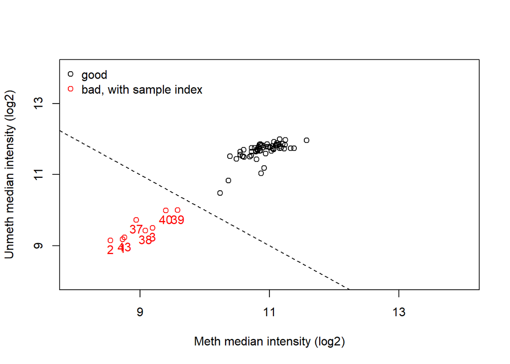

```r
##phenotype data
pheno <- pData(rg_array)

#getQC
qc_info <- getQC(mset_array)
plotQC(qc_info, badSampleCutoff = 10)
```

```r
#normalize
array_norm <- preprocessFunnorm(rg_array)
```

```
## [preprocessFunnorm] Background and dye bias correction with noob
```

```
## [preprocessFunnorm] Mapping to genome
```

```
## [preprocessFunnorm] Quantile extraction
```

```
## [preprocessFunnorm] Normalization
```

```r
head(array_norm)
```

```
## class: GenomicRatioSet
## dim: 6 72
## metadata(0):
## assays(2): Beta CN
## rownames(6): cg13869341 cg14008030 ... cg00381604 cg20253340
## rowData names(0):
## colnames(72): GSM1855609_9020331147_R02C02 GSM1855610_9020331147_R03C02 ... GSM1855679_9421912040_R02C02 GSM1855680_9421912040_R03C02
## colData names(16): Basename SampleID ... yMed predictedSex
## Annotation
##   array: IlluminaHumanMethylation450k
##   annotation: ilmn12.hg19
## Preprocessing
##   Method: NA
##   minfi version: NA
##   Manifest version: NA
```

```r
summary_norm <- shinySummarize(array_norm)
```

```
## [shinySummarize] Computing methylation values
## [shinySummarize] Computing quantiles
## [shinySummarize] Computing principal components
```

```r
head(summary_norm@phenotype)
```

```
##                                                  Basename   SampleID Sample_type           tissue     organism casecontrolstatus Sex pma_birth Steriods_birth  Sample_label_protocol_ch1 Sample_platform_id Sample_data_row_count                                                                     fil…
## GSM1855609_9020331147_R02C02 GSM1855609_9020331147_R02C02 GSM1855609     genomic saliva_full term Homo sapiens         full_term   F     41.28           <NA> Standard Illumina Protocol           GPL13534                372759 C:/Users/alexaw/Documents/EPID 600/GSE72120/idat/GSM1855609_9020331147_…
## GSM1855610_9020331147_R03C02 GSM1855610_9020331147_R03C02 GSM1855610     genomic saliva_full term Homo sapiens         full_term   M     40.57           <NA> Standard Illumina Protocol           GPL13534                372759 C:/Users/alexaw/Documents/EPID 600/GSE72120/idat/GSM1855610_9020331147_…
## GSM1855611_9020331147_R04C02 GSM1855611_9020331147_R04C02 GSM1855611     genomic saliva_full term Homo sapiens         full_term   M     39.43           <NA> Standard Illumina Protocol           GPL13534                372759 C:/Users/alexaw/Documents/EPID 600/GSE72120/idat/GSM1855611_9020331147_…
## GSM1855612_9020331147_R05C02 GSM1855612_9020331147_R05C02 GSM1855612     genomic saliva_full term Homo sapiens         full_term   F     38.14           <NA> Standard Illumina Protocol           GPL13534                372759 C:/Users/alexaw/Documents/EPID 600/GSE72120/idat/GSM1855612_9020331147_…
## GSM1855613_9020331147_R06C02 GSM1855613_9020331147_R06C02 GSM1855613     genomic saliva_full term Homo sapiens         full_term   F     38.84           <NA> Standard Illumina Protocol           GPL13534                372759 C:/Users/alexaw/Documents/EPID 600/GSE72120/idat/GSM1855613_9020331147_…
## GSM1855614_9647455135_R04C01 GSM1855614_9647455135_R04C01 GSM1855614     genomic saliva_full term Homo sapiens         full_term   M     40.14             No Standard Illumina Protocol           GPL13534                372759 C:/Users/alexaw/Documents/EPID 600/GSE72120/idat/GSM1855614_9647455135_…
```

## Data Visualization

```r
#Run ShinyMethyl for visualization and QC
runShinyMethyl(summary_array, summary_norm) #compares normal and non-normalized data
```

# Remove SNPs

```r
array_snps <- getSnpInfo(array_norm)
array_qc <- dropLociWithSnps(array_norm, snps=c("SBE","CpG"), maf=0)
```

## Differential Methylation: The minfi and bumphunter packages were utilized to find differentially methylated positions and regions (DMRs) in the dataset.“Positions” refer to individual CpG probes, while “regions” over a number of bases can have one or more probes. In finding DMRs, the data was resampled 100 times, then the output was annotated using the list of known genes in hg19 from the University of California, Santa Cruz. A total of 274 DMRs were identified.

```r
#dmpFinder for differentially methylated positions
beta_array <- getBeta(array_qc) #no warning here
casecontrol <- pData(array_qc)$casecontrolstatus
dmp_casecont <- dmpFinder(beta_array, pheno = casecontrol, type = "categorical")
head(dmp_casecont)
```

```
##            intercept        f         pval         qval
## cg13985639 0.7161620 92.51219 1.964056e-14 5.355675e-09
## cg05835276 0.2438698 91.14363 2.648720e-14 5.355675e-09
## cg24838825 0.4781488 85.25626 9.883057e-14 1.332227e-08
## cg03512250 0.6404929 79.88420 3.438155e-13 3.423998e-08
## cg03138364 0.5218075 79.00622 4.233458e-13 3.423998e-08
## cg17164954 0.2039173 76.28622 8.131236e-13 5.480416e-08
```

```r
#bumphunter for differentially methylated regions
matrix <- model.matrix(~ casecontrol)
dmrs <- bumphunter(array_qc, design = matrix,
             cutoff = 0.1, B=0, type="Beta") #can mess with these cutoff values
```

```
## [bumphunterEngine] Using a single core (backend: doSEQ, version: 1.4.4).
```

```
## [bumphunterEngine] Computing coefficients.
```

```
## [bumphunterEngine] Finding regions.
```

```
## [bumphunterEngine] Found 274 bumps.
```

```r
#run permutations
dmrs <- bumphunter(array_qc, design = matrix,
             cutoff = 0.10, B=100, type="Beta")
```

```
## [bumphunterEngine] Using a single core (backend: doSEQ, version: 1.4.4).
```

```
## [bumphunterEngine] Computing coefficients.
```

```
## [bumphunterEngine] Performing 100 permutations.
```

```
## [bumphunterEngine] Computing marginal permutation p-values.
```

```
## [bumphunterEngine] cutoff: 0.1
```

```
## [bumphunterEngine] Finding regions.
```

```
## [bumphunterEngine] Found 274 bumps.
```

```
## [bumphunterEngine] Computing regions for each permutation.
```

```
## [bumphunterEngine] Estimating p-values and FWER.
```

```r
dmrs2 <- as.data.frame(dmrs$table)
#annotate DMRs
library(TxDb.Hsapiens.UCSC.hg19.knownGene)
hg19_annotated <- annotateTranscripts(TxDb.Hsapiens.UCSC.hg19.knownGene, by = c("gene"))
```

```
## No annotationPackage supplied. Trying org.Hs.eg.db.
```

```
## Getting TSS and TSE.
```

```
## Getting CSS and CSE.
```

```
## Getting exons.
```

```
## Annotating genes.
```

```r
dmrs_anno <- annotateNearest(dmrs$table, hg19_annotated)
head(dmrs_anno)
```

```
##   distance subjectHits     type amountOverlap insideDist size1  size2
## 1        0        8155   inside            NA       4542   114  34106
## 2        0        6836   inside            NA    -262984     1 621882
## 3  1248120        9841 disjoint            NA         NA    22  72460
## 4      621       10128 disjoint            NA         NA    23  16372
## 5        0        9958  overlap          -116         NA   216 124714
## 6        0       16483   inside            NA      12407    95  42884
```

```r
annoTx <- annotateTranscripts(TxDb.Hsapiens.UCSC.hg19.knownGene)
```

```
## No annotationPackage supplied. Trying org.Hs.eg.db.
```

```
## Getting TSS and TSE.
```

```
## Getting CSS and CSE.
```

```
## Getting exons.
```

```
## Annotating genes.
```

```r
match <- matchGenes(dmrs$table, annoTx)
```

```
## ..
```

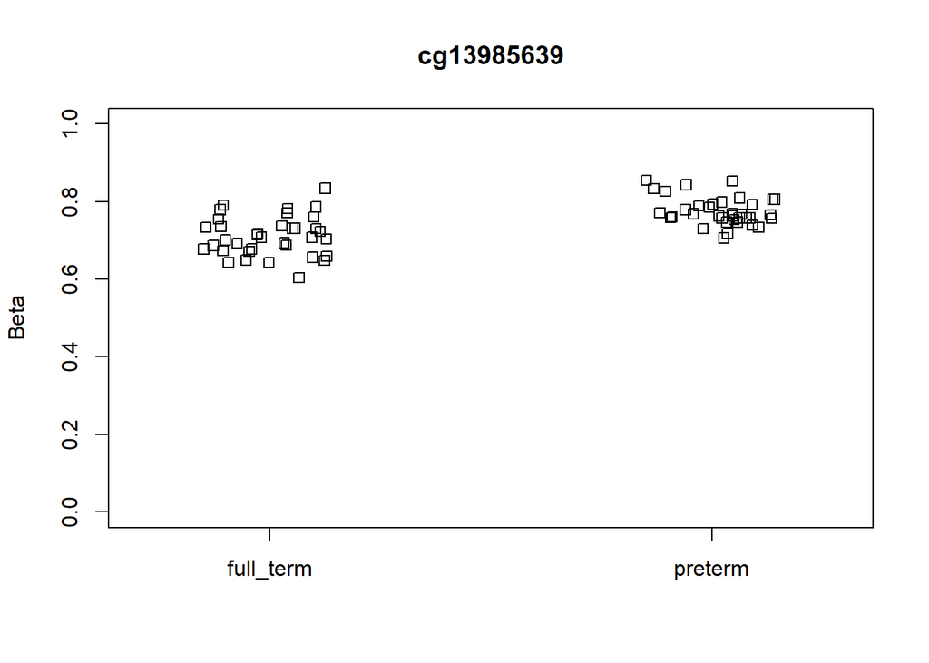

```r
#Visualizing a specific DMP
plotCpg(mset_array, cpg = "cg13985639", pheno = targetarray$casecontrolstatus, type = c("categorical"),
  measure = c("beta"))
```

# Pull potential features from phenotype data

```r
#make dataframe with potential features
featurelist <-  as.data.frame(targetarray[2:9])
featurelist[,2:4] <- NULL
featurelist$SampleID <- as.factor(featurelist$SampleID)
featurelist$Sex <- as.factor(featurelist$Sex)
featurelist$pma_birth <- as.factor(featurelist$pma_birth)
featurelist$Steriods_birth <- as.factor(featurelist$Steriods_birth)

#get M (intensity) values
Mval_cpg <- as.data.frame(getM(array_qc))
```